# Tipología y ciclo de vida de los datos - Práctica 2

Paula Moreno y David Cosialls

15 de June, 2023

# 1 Introducción

El objetivo de esta práctica es identificar los datos relevantes en un proyecto analítico y usar las herramientas de integración, limpieza, validación y análisis de los datos. Para ello vamos a utilizar un dataset que hemos obtenido de la plataforma Kagle. Los datos que hemos elegido son los siguiente: https://www.kaggle.com/datasets/arashnic/fitbit

Este dataset nos presenta un conjunto de datos recolectados desde un smartwatch que recoge la información de salud de su usuario. Tenemos información relativa al ritmo cardíaco, al sueño, nivel de actividad física, calorías consumidas, el peso y los pasos realizados.

Este dataset contiene tres archivos .csv que explicamos a continuación:

- El primer archivo, dailyActivity_merged.csv, trata sobre la actividad diaria de un usuario y, contiene los datos sobre el número de pasos realizados, la distancia total recorrida, y diversos datos que categorizan el tipo de actividad que se ha realizado midiendolas en tiempo y distancia, además de las calorías que ha quemado. Un ejemplo, es un usuario que a lo largo de un día ha realizado 13.162 pasos, con una distancia total recorrida de 8.5 Km. De estos 8.5 Km, 1.87 Km se han realizado en una alta intensidad, 0.5 Km en una intensidad moderada y el resto, 6.05 Km en un paso tranquilo, caminando. Se cuantifica que el usuario ha estado 25 minutos muy activo, 13 min. bastante activo, 328 min. algo activo y 728 en modo sedentario. En total en este periodo de actividad ha consumido 1985 calorías.
- El segundo archivo, sleepDay_merged.csv, trata sobre el sueño durante un día de un usuario. Los datos que se recogen en este dataset son el día que grabó el sueño, cuántas veces se grabó, cuántos minutos ha dormido y cuánto tiempo ha estado en la cama. Por ejemplo este usuario el día 12 de abril del 2016, grabó 1 etapa de sueño donde estuvo en la cama durante 346 minutos de los cuales 327 los pasó durmiendo.
- El tercer archivo, heartrate_second_merged.csv, trata sobre el registro del pulso cada 5 segundos durante el transcurso de varios días. La primera muestra de este dataset muestra que el usuario el día 12 de abril del 2016 tenía un pulso cardíaco de 97 pulsaciones por minuto a las 7:21:00 de la mañana.

El objetivo de analizar estos tres datasets es comprobar la correlación que existe entre la actividad y el pulso que un usuario registra a lo largo del día y cómo afecta a la calidad del sueño. Para ello vamos a utilizar estos tres datasets que nos brindan la oportunidad de tratar con datos reales de un usuario.

# 2 Carga de los archivos

El primer paso es leer el dataset para poder empezar a tratar los datos. En nuestro caso concreto vamos a utilizar los datos de tres archivos diferentes:

- dailyActivity_merged.csv
- heartrate_seconds_merged.csv
- sleepDay_merged.csv

```r
df_activity <- read.csv('../datos originales/dailyActivity_merged.csv')
df_heartrate <- read.csv('../datos originales/heartrate_seconds_merged.csv')
df_sleep <- read.csv('../datos originales/sleepDay_merged.csv')
```

```r
length(unique(df_activity$Id))
```

```
## [1] 33
```

```r
length(unique(df_heartrate$Id))
```

```
## [1] 14
```

```r
length(unique(df_sleep$Id))
```

```
## [1] 24
```

```r
length(intersect(unique(df_sleep$Id),intersect(unique(df_activity$Id),unique(df_heartrate$Id))))
```

```
## [1] 12
```

# 3 Limpieza de los datos

## 3.1 Unificar los datasets

```r
head(df_activity)
```

```
##           Id ActivityDate TotalSteps TotalDistance TrackerDistance
## 1 1503960366    4/12/2016      13162          8.50            8.50
## 2 1503960366    4/13/2016      10735          6.97            6.97
## 3 1503960366    4/14/2016      10460          6.74            6.74
## 4 1503960366    4/15/2016       9762          6.28            6.28
## 5 1503960366    4/16/2016      12669          8.16            8.16
## 6 1503960366    4/17/2016       9705          6.48            6.48
##   LoggedActivitiesDistance VeryActiveDistance ModeratelyActiveDistance
## 1                        0               1.88                     0.55
## 2                        0               1.57                     0.69
## 3                        0               2.44                     0.40
## 4                        0               2.14                     1.26
## 5                        0               2.71                     0.41
## 6                        0               3.19                     0.78
##   LightActiveDistance SedentaryActiveDistance VeryActiveMinutes
## 1                6.06                       0                25
## 2                4.71                       0                21
## 3                3.91                       0                30
## 4                2.83                       0                29
## 5                5.04                       0                36
## 6                2.51                       0                38
##   FairlyActiveMinutes LightlyActiveMinutes SedentaryMinutes Calories
## 1                  13                  328              728     1985
## 2                  19                  217              776     1797
## 3                  11                  181             1218     1776
## 4                  34                  209              726     1745
## 5                  10                  221              773     1863
## 6                  20                  164              539     1728
```

```r
head(df_heartrate)
```

```
##           Id                 Time Value
## 1 2022484408 4/12/2016 7:21:00 AM    97
## 2 2022484408 4/12/2016 7:21:05 AM   102
## 3 2022484408 4/12/2016 7:21:10 AM   105
## 4 2022484408 4/12/2016 7:21:20 AM   103
## 5 2022484408 4/12/2016 7:21:25 AM   101
## 6 2022484408 4/12/2016 7:22:05 AM    95
```

```r
head(df_sleep)
```

```
##           Id              SleepDay TotalSleepRecords TotalMinutesAsleep
## 1 1503960366 4/12/2016 12:00:00 AM                 1                327
## 2 1503960366 4/13/2016 12:00:00 AM                 2                384
## 3 1503960366 4/15/2016 12:00:00 AM                 1                412
## 4 1503960366 4/16/2016 12:00:00 AM                 2                340
## 5 1503960366 4/17/2016 12:00:00 AM                 1                700
## 6 1503960366 4/19/2016 12:00:00 AM                 1                304
##   TotalTimeInBed
## 1            346
## 2            407
## 3            442
## 4            367
## 5            712
## 6            320
```

Como hemos podido observar tenemos 12 id’s que coincidan en los tres datasets, por lo que unificaremos en base a ese id y a la fecha del registro. En los tres dataset tenemos tres formatos de fechas diferentes. Para poder unificarlos lo que haremos será, en el caso del dataset del sueño quitar la hora ya que todos los registros son de la misma hora, solo cambia el día. En el caso del dataset del ritmo cardíaco calcularemos la media por día y será ese dato el que incluiremos en el dataset de la actividad general.

Pero primero debemos comprobar que los tipos de datos que tenemos en el datset de activity es el adecuado. Como podemos observar el tipo de dato de las fechas es un string por lo que lo transformaremos a tipo date:

```r
str(df_activity)
```

```
## 'data.frame':    940 obs. of  15 variables:
##  $ Id                      : num  1.5e+09 1.5e+09 1.5e+09 1.5e+09 1.5e+09 ...
##  $ ActivityDate            : chr  "4/12/2016" "4/13/2016" "4/14/2016" "4/15/2016" ...
##  $ TotalSteps              : int  13162 10735 10460 9762 12669 9705 13019 15506 10544 9819 ...
##  $ TotalDistance           : num  8.5 6.97 6.74 6.28 8.16 ...
##  $ TrackerDistance         : num  8.5 6.97 6.74 6.28 8.16 ...
##  $ LoggedActivitiesDistance: num  0 0 0 0 0 0 0 0 0 0 ...
##  $ VeryActiveDistance      : num  1.88 1.57 2.44 2.14 2.71 ...
##  $ ModeratelyActiveDistance: num  0.55 0.69 0.4 1.26 0.41 ...
##  $ LightActiveDistance     : num  6.06 4.71 3.91 2.83 5.04 ...
##  $ SedentaryActiveDistance : num  0 0 0 0 0 0 0 0 0 0 ...
##  $ VeryActiveMinutes       : int  25 21 30 29 36 38 42 50 28 19 ...
##  $ FairlyActiveMinutes     : int  13 19 11 34 10 20 16 31 12 8 ...
##  $ LightlyActiveMinutes    : int  328 217 181 209 221 164 233 264 205 211 ...
##  $ SedentaryMinutes        : int  728 776 1218 726 773 539 1149 775 818 838 ...
##  $ Calories                : int  1985 1797 1776 1745 1863 1728 1921 2035 1786 1775 ...
```

Tenemos 31 fechas diferentes en el formato ingles, es decir, MM/DD/YYYY primero el mes y después el día:

```r
unique(df_activity$ActivityDate)
```

```
##  [1] "4/12/2016" "4/13/2016" "4/14/2016" "4/15/2016" "4/16/2016" "4/17/2016"
##  [7] "4/18/2016" "4/19/2016" "4/20/2016" "4/21/2016" "4/22/2016" "4/23/2016"
## [13] "4/24/2016" "4/25/2016" "4/26/2016" "4/27/2016" "4/28/2016" "4/29/2016"
## [19] "4/30/2016" "5/1/2016"  "5/2/2016"  "5/3/2016"  "5/4/2016"  "5/5/2016"
## [25] "5/6/2016"  "5/7/2016"  "5/8/2016"  "5/9/2016"  "5/10/2016" "5/11/2016"
## [31] "5/12/2016"
```

```r
sum(is.na(df_activity$ActivityDate))
```

```
## [1] 0
```

```r
df_activity$ActivityDate <- as.Date(df_activity$ActivityDate,format="%m/%d/%Y")
```

```r
str(df_activity)
```

```
## 'data.frame':    940 obs. of  15 variables:
##  $ Id                      : num  1.5e+09 1.5e+09 1.5e+09 1.5e+09 1.5e+09 ...
##  $ ActivityDate            : Date, format: "2016-04-12" "2016-04-13" ...
##  $ TotalSteps              : int  13162 10735 10460 9762 12669 9705 13019 15506 10544 9819 ...
##  $ TotalDistance           : num  8.5 6.97 6.74 6.28 8.16 ...
##  $ TrackerDistance         : num  8.5 6.97 6.74 6.28 8.16 ...
##  $ LoggedActivitiesDistance: num  0 0 0 0 0 0 0 0 0 0 ...
##  $ VeryActiveDistance      : num  1.88 1.57 2.44 2.14 2.71 ...
##  $ ModeratelyActiveDistance: num  0.55 0.69 0.4 1.26 0.41 ...
##  $ LightActiveDistance     : num  6.06 4.71 3.91 2.83 5.04 ...
##  $ SedentaryActiveDistance : num  0 0 0 0 0 0 0 0 0 0 ...
##  $ VeryActiveMinutes       : int  25 21 30 29 36 38 42 50 28 19 ...
##  $ FairlyActiveMinutes     : int  13 19 11 34 10 20 16 31 12 8 ...
##  $ LightlyActiveMinutes    : int  328 217 181 209 221 164 233 264 205 211 ...
##  $ SedentaryMinutes        : int  728 776 1218 726 773 539 1149 775 818 838 ...
##  $ Calories                : int  1985 1797 1776 1745 1863 1728 1921 2035 1786 1775 ...
```

Una vez ya tenemos el tipo de dato adecuado realizaremos el mismo proceso para el dataset del sueño, pero en este caso debemos quitar la hora:

```r
str(df_sleep)
```

```
## 'data.frame':    413 obs. of  5 variables:
##  $ Id                : num  1.5e+09 1.5e+09 1.5e+09 1.5e+09 1.5e+09 ...
##  $ SleepDay          : chr  "4/12/2016 12:00:00 AM" "4/13/2016 12:00:00 AM" "4/15/2016 12:00:00 AM" "4/16/2016 12:00:00 AM" ...
##  $ TotalSleepRecords : int  1 2 1 2 1 1 1 1 1 1 ...
##  $ TotalMinutesAsleep: int  327 384 412 340 700 304 360 325 361 430 ...
##  $ TotalTimeInBed    : int  346 407 442 367 712 320 377 364 384 449 ...
```

```r
df_sleep$ActivityDate <- as.Date(df_sleep$SleepDay,format = "%m/%d/%Y")
df_sleep <- df_sleep[,-which(names(df_sleep) == "SleepDay")]
```

De esta forma tenemos el mismo formato de fecha y el mismo nombre para la columna que con el dataset de activad. De esta forma podremos hacer el merge de ambos datasets utilizando las variables de id y fecha como criterio.

```r
str(df_sleep)
```

```
## 'data.frame':    413 obs. of  5 variables:
##  $ Id                : num  1.5e+09 1.5e+09 1.5e+09 1.5e+09 1.5e+09 ...
##  $ TotalSleepRecords : int  1 2 1 2 1 1 1 1 1 1 ...
##  $ TotalMinutesAsleep: int  327 384 412 340 700 304 360 325 361 430 ...
##  $ TotalTimeInBed    : int  346 407 442 367 712 320 377 364 384 449 ...
##  $ ActivityDate      : Date, format: "2016-04-12" "2016-04-13" ...
```

```r
df <- merge(df_activity,df_sleep,by=c("Id","ActivityDate"))
```

```r
head(df)
```

```
##           Id ActivityDate TotalSteps TotalDistance TrackerDistance
## 1 1503960366   2016-04-12      13162          8.50            8.50
## 2 1503960366   2016-04-13      10735          6.97            6.97
## 3 1503960366   2016-04-15       9762          6.28            6.28
## 4 1503960366   2016-04-16      12669          8.16            8.16
## 5 1503960366   2016-04-17       9705          6.48            6.48
## 6 1503960366   2016-04-19      15506          9.88            9.88
##   LoggedActivitiesDistance VeryActiveDistance ModeratelyActiveDistance
## 1                        0               1.88                     0.55
## 2                        0               1.57                     0.69
## 3                        0               2.14                     1.26
## 4                        0               2.71                     0.41
## 5                        0               3.19                     0.78
## 6                        0               3.53                     1.32
##   LightActiveDistance SedentaryActiveDistance VeryActiveMinutes
```

[output cut: 20 more lines]

Ya tenemos un dataset donde hemos podido unir el dataset de actividad con el de sueño. Ahora debemos hacer lo mismo con el dataset del ritmo cardíaco. Para este caso debemos transformar la fecha en tipo date y calcular la media para cada día, será este dato el que uniremos a nuestro nuevo dateset.

```r
str(df_heartrate)
```

```
## 'data.frame':    2483658 obs. of  3 variables:
##  $ Id   : num  2.02e+09 2.02e+09 2.02e+09 2.02e+09 2.02e+09 ...
##  $ Time : chr  "4/12/2016 7:21:00 AM" "4/12/2016 7:21:05 AM" "4/12/2016 7:21:10 AM" "4/12/2016 7:21:20 AM" ...
##  $ Value: int  97 102 105 103 101 95 91 93 94 93 ...
```

```r
df_heartrate$ActivityDate <- as.Date(df_heartrate$Time,format = "%m/%d/%Y")
```

```r
str(df_heartrate)
```

```
## 'data.frame':    2483658 obs. of  4 variables:
##  $ Id          : num  2.02e+09 2.02e+09 2.02e+09 2.02e+09 2.02e+09 ...
##  $ Time        : chr  "4/12/2016 7:21:00 AM" "4/12/2016 7:21:05 AM" "4/12/2016 7:21:10 AM" "4/12/2016 7:21:20 AM" ...
##  $ Value       : int  97 102 105 103 101 95 91 93 94 93 ...
##  $ ActivityDate: Date, format: "2016-04-12" "2016-04-12" ...
```

Una vez obtenida solo la fecha vamos a generar un nuevo dataset con la media:

```r
df_heartrate_mean <- aggregate(Value ~ ActivityDate+Id, data=df_heartrate, FUN=mean)
names(df_heartrate_mean)[3]<-"HeartrateMean"
head(df_heartrate_mean)
```

```
##   ActivityDate         Id HeartrateMean
## 1   2016-04-12 2022484408      75.80418
## 2   2016-04-13 2022484408      80.33758
## 3   2016-04-14 2022484408      72.62860
## 4   2016-04-15 2022484408      80.43738
## 5   2016-04-16 2022484408      75.96055
## 6   2016-04-17 2022484408      83.91714
```

Ahora ya podemos hacer el merge:

```r
df <- merge(df,df_heartrate_mean,by=c("Id","ActivityDate"))
head(df)
```

```
##           Id ActivityDate TotalSteps TotalDistance TrackerDistance
## 1 2026352035   2016-04-17        838          0.52            0.52
## 2 2026352035   2016-04-25       6017          3.73            3.73
## 3 2026352035   2016-05-02       7018          4.35            4.35
## 4 2026352035   2016-05-09      10685          6.62            6.62
## 5 2347167796   2016-04-13      10352          7.01            7.01
## 6 2347167796   2016-04-14      10129          6.70            6.70
##   LoggedActivitiesDistance VeryActiveDistance ModeratelyActiveDistance
## 1                        0               0.00                     0.00
## 2                        0               0.00                     0.00
## 3                        0               0.00                     0.00
## 4                        0               0.00                     0.00
## 5                        0               1.66                     1.94
## 6                        0               0.02                     2.74
##   LightActiveDistance SedentaryActiveDistance VeryActiveMinutes
```

[output cut: 20 more lines]

Ahora ya tenemos un dataset con todos los datos unificados.

## 3.2 Datos vacíos

En este apartado vamos a comprobar que toda la información que tenemos esta completa y que no hay datos vacíos:

```r
str(df)
```

```
## 'data.frame':    182 obs. of  19 variables:
##  $ Id                      : num  2.03e+09 2.03e+09 2.03e+09 2.03e+09 2.35e+09 ...
##  $ ActivityDate            : Date, format: "2016-04-17" "2016-04-25" ...
##  $ TotalSteps              : int  838 6017 7018 10685 10352 10129 10465 5472 8247 6711 ...
##  $ TotalDistance           : num  0.52 3.73 4.35 6.62 7.01 ...
##  $ TrackerDistance         : num  0.52 3.73 4.35 6.62 7.01 ...
##  $ LoggedActivitiesDistance: num  0 0 0 0 0 0 0 0 0 0 ...
##  $ VeryActiveDistance      : num  0 0 0 0 1.66 ...
##  $ ModeratelyActiveDistance: num  0 0 0 0 1.94 ...
##  $ LightActiveDistance     : num  0.52 3.73 4.35 6.6 3.41 ...
##  $ SedentaryActiveDistance : num  0 0 0 0 0 0 0 0 0 0 ...
##  $ VeryActiveMinutes       : int  0 0 0 0 19 1 1 1 11 0 ...
##  $ FairlyActiveMinutes     : int  0 0 0 0 32 48 24 7 16 7 ...
##  $ LightlyActiveMinutes    : int  60 260 355 401 195 206 284 249 206 382 ...
##  $ SedentaryMinutes        : int  1053 821 716 543 676 705 720 508 678 648 ...
##  $ Calories                : int  1214 1576 1690 1869 2038 2010 2133 1882 1944 2346 ...
##  $ TotalSleepRecords       : int  1 1 1 1 1 1 1 1 1 1 ...
##  $ TotalMinutesAsleep      : int  437 506 511 531 467 445 452 556 500 465 ...
##  $ TotalTimeInBed          : int  498 531 543 556 531 489 504 602 557 514 ...
##  $ HeartrateMean           : num  68.7 99.5 84.1 98.2 73.8 ...
```

```r
summary(df)
```

```
##        Id             ActivityDate          TotalSteps    TotalDistance
##  Min.   :2.026e+09   Min.   :2016-04-12   Min.   :   42   Min.   : 0.030
##  1st Qu.:4.388e+09   1st Qu.:2016-04-19   1st Qu.: 5265   1st Qu.: 3.685
##  Median :5.577e+09   Median :2016-04-26   Median : 9160   Median : 6.400
##  Mean   :5.566e+09   Mean   :2016-04-26   Mean   : 8528   Mean   : 6.029
##  3rd Qu.:6.962e+09   3rd Qu.:2016-05-03   3rd Qu.:11112   3rd Qu.: 7.912
##  Max.   :8.792e+09   Max.   :2016-05-12   Max.   :22770   Max.   :17.540
##  TrackerDistance  LoggedActivitiesDistance VeryActiveDistance
##  Min.   : 0.030   Min.   :0.00000          Min.   :0.000
##  1st Qu.: 3.685   1st Qu.:0.00000          1st Qu.:0.000
##  Median : 6.400   Median :0.00000          Median :0.650
##  Mean   : 6.017   Mean   :0.05514          Mean   :1.425
##  3rd Qu.: 7.888   3rd Qu.:0.00000          3rd Qu.:2.408
##  Max.   :17.540   Max.   :4.08169          Max.   :9.890
##  ModeratelyActiveDistance LightActiveDistance SedentaryActiveDistance
##  Min.   :0.0000           Min.   :0.030       Min.   :0.000000
##  1st Qu.:0.0000           1st Qu.:2.672       1st Qu.:0.000000
##  Median :0.4000           Median :3.770       Median :0.000000
##  Mean   :0.6531           Mean   :3.901       Mean   :0.002088
##  3rd Qu.:1.0300           3rd Qu.:5.253       3rd Qu.:0.000000
##  Max.   :2.7700           Max.   :9.480       Max.   :0.110000
##  VeryActiveMinutes FairlyActiveMinutes LightlyActiveMinutes SedentaryMinutes
##  Min.   :  0.00    Min.   : 0.00       Min.   :  4.0        Min.   :   2.0
##  1st Qu.:  0.00    1st Qu.: 0.00       1st Qu.:176.2        1st Qu.: 621.2
##  Median : 12.00    Median :13.50       Median :226.5        Median : 707.5
##  Mean   : 27.91    Mean   :16.72       Mean   :228.5        Mean   : 703.0
##  3rd Qu.: 38.00    3rd Qu.:29.00       3rd Qu.:276.5        3rd Qu.: 781.0
##  Max.   :210.00    Max.   :74.00       Max.   :518.0        Max.   :1222.0
##     Calories    TotalSleepRecords TotalMinutesAsleep TotalTimeInBed
##  Min.   : 403   Min.   :1.000     Min.   : 58.0      Min.   : 61.0
##  1st Qu.:1994   1st Qu.:1.000     1st Qu.:391.0      1st Qu.:413.2
##  Median :2225   Median :1.000     Median :439.0      Median :464.0
##  Mean   :2469   Mean   :1.121     Mean   :426.5      Mean   :455.0
##  3rd Qu.:2995   3rd Qu.:1.000     3rd Qu.:491.2      3rd Qu.:525.0
##  Max.   :4900   Max.   :3.000     Max.   :775.0      Max.   :843.0
##  HeartrateMean
##  Min.   : 59.38
##  1st Qu.: 67.05
##  Median : 73.04
##  Mean   : 73.62
##  3rd Qu.: 79.37
##  Max.   :104.87
```

En el summary podemos observar que no hay datos NA pero si que hay tres columnas que podemos sospechar que aporten muy poca información, se trata de las tres siguientes:

- LoggedActivitiesDistance
- SedentaryActiveDistance
- TotalSleepRecords

Vamos a estudiar esas tres columnas para comprobar is aportan información al dataset o no:

```r
summary(df[,c("LoggedActivitiesDistance","SedentaryActiveDistance","TotalSleepRecords")])
```

```
##  LoggedActivitiesDistance SedentaryActiveDistance TotalSleepRecords
##  Min.   :0.00000          Min.   :0.000000        Min.   :1.000
##  1st Qu.:0.00000          1st Qu.:0.000000        1st Qu.:1.000
##  Median :0.00000          Median :0.000000        Median :1.000
##  Mean   :0.05514          Mean   :0.002088        Mean   :1.121
##  3rd Qu.:0.00000          3rd Qu.:0.000000        3rd Qu.:1.000
##  Max.   :4.08169          Max.   :0.110000        Max.   :3.000
```

```r
sum(df$LoggedActivitiesDistance>0)
```

```
## [1] 3
```

```r
sum(df$SedentaryActiveDistance>0)
```

```
## [1] 6
```

```r
unique(df$TotalSleepRecords)
```

```
## [1] 1 2 3
```

```r
table(df$TotalSleepRecords)
```

```
##
##   1   2   3
## 162  18   2
```

En el caso de las variables LoggedActivitiesDistance y SedentaryActiveDistance la mayoria de datos observado son 0 por lo que apenas aportan información nueva por lo que vamos a quitar esas dos variables. Para el caso de TotalSleepRecords representa el numero de registros de sueño que se tienen de ese día para ese id. Pero luego tenemos el recuento total de tiempo que la persona ha dormido y el recuento total del tiempo que se a pasado tumbado. Por lo que esa columna no aporta información nueva. También la vamos a quitar:

```r
library(dplyr)
df <- df[, -which(names(df) %in% c("LoggedActivitiesDistance","SedentaryActiveDistance","TotalSleepRecords"))]
```

## 3.3 Valores atípicos y extremos

Tras haber eliminado alguna de las variables vamos a volver a visualizar el resumen de todos los datos:

```r
summary(df)
```

```
##        Id             ActivityDate          TotalSteps    TotalDistance
##  Min.   :2.026e+09   Min.   :2016-04-12   Min.   :   42   Min.   : 0.030
##  1st Qu.:4.388e+09   1st Qu.:2016-04-19   1st Qu.: 5265   1st Qu.: 3.685
##  Median :5.577e+09   Median :2016-04-26   Median : 9160   Median : 6.400
##  Mean   :5.566e+09   Mean   :2016-04-26   Mean   : 8528   Mean   : 6.029
##  3rd Qu.:6.962e+09   3rd Qu.:2016-05-03   3rd Qu.:11112   3rd Qu.: 7.912
##  Max.   :8.792e+09   Max.   :2016-05-12   Max.   :22770   Max.   :17.540
##  TrackerDistance  VeryActiveDistance ModeratelyActiveDistance
##  Min.   : 0.030   Min.   :0.000      Min.   :0.0000
##  1st Qu.: 3.685   1st Qu.:0.000      1st Qu.:0.0000
##  Median : 6.400   Median :0.650      Median :0.4000
##  Mean   : 6.017   Mean   :1.425      Mean   :0.6531
##  3rd Qu.: 7.888   3rd Qu.:2.408      3rd Qu.:1.0300
##  Max.   :17.540   Max.   :9.890      Max.   :2.7700
##  LightActiveDistance VeryActiveMinutes FairlyActiveMinutes LightlyActiveMinutes
##  Min.   :0.030       Min.   :  0.00    Min.   : 0.00       Min.   :  4.0
##  1st Qu.:2.672       1st Qu.:  0.00    1st Qu.: 0.00       1st Qu.:176.2
##  Median :3.770       Median : 12.00    Median :13.50       Median :226.5
##  Mean   :3.901       Mean   : 27.91    Mean   :16.72       Mean   :228.5
##  3rd Qu.:5.253       3rd Qu.: 38.00    3rd Qu.:29.00       3rd Qu.:276.5
##  Max.   :9.480       Max.   :210.00    Max.   :74.00       Max.   :518.0
##  SedentaryMinutes    Calories    TotalMinutesAsleep TotalTimeInBed
##  Min.   :   2.0   Min.   : 403   Min.   : 58.0      Min.   : 61.0
##  1st Qu.: 621.2   1st Qu.:1994   1st Qu.:391.0      1st Qu.:413.2
##  Median : 707.5   Median :2225   Median :439.0      Median :464.0
##  Mean   : 703.0   Mean   :2469   Mean   :426.5      Mean   :455.0
##  3rd Qu.: 781.0   3rd Qu.:2995   3rd Qu.:491.2      3rd Qu.:525.0
##  Max.   :1222.0   Max.   :4900   Max.   :775.0      Max.   :843.0
##  HeartrateMean
##  Min.   : 59.38
##  1st Qu.: 67.05
##  Median : 73.04
##  Mean   : 73.62
##  3rd Qu.: 79.37
##  Max.   :104.87
```

El único caso que nos llama la atención sería el HeartrateMean, ya que un ritmo cardíaco de 104 es muy elevado pero no imposible por lo que lo podríamos considerar un valor atípico vamos a gráficar dicha variable para ver si es el caso:

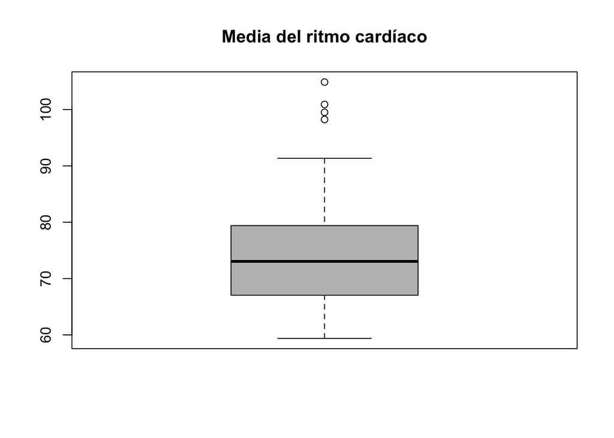

```r
boxplot(df$HeartrateMean,main='Media del ritmo cardíaco',col='gray')
```

```r
boxplot.stats(df$HeartrateMean)
```

```
## $stats
## [1] 59.37717 67.04068 73.04370 79.40156 91.33540
##
## $n
## [1] 182
##
## $conf
## [1] 71.59602 74.49137
##
## $out
## [1]  99.50581  98.23390 100.90332 104.87147
```

Otro de los datos que nos pueden llamar la atención es el máximo de minutos dormidos, 775, que corresponde con casi 13 horas de sueño. Es un valor muy elevado pero posible por lo que tampoco es un error. Vamos a generar el mismo gráfico que para la variable anterior para ver cuantos valores alejados del resto obtenemos:

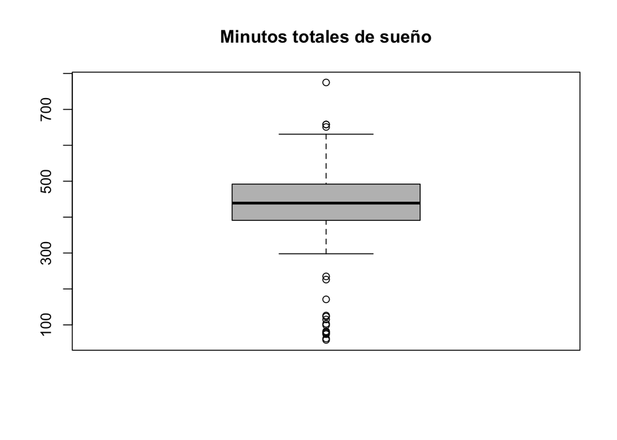

```r
boxplot(df$TotalMinutesAsleep,main='Minutos totales de sueño',col='gray')
```

En este caso observamos que tenemos casos atípicos tanto en el máximo como en el mínimo.

```r
boxplot.stats(df$TotalMinutesAsleep)
```

```
## $stats
## [1] 298 391 439 492 631
##
## $n
## [1] 182
##
## $conf
## [1] 427.1711 450.8289
##
## $out
##  [1]  77 226  99  82  62 126 103 171 115 123 651 658 775  74 658 235  79  58
```

En todos los casos son datos que son posibles por lo que no son un error y los mantendremos en nuestro dataset.

# 4 Creación de nuevas variables

Para nuestro caso de estudio vamos a crear una nueva variable condicional, es decir, un booleano que representará si esa persona a podido dormir mas de 8 horas. Ya que son las recomendadas:

```r
df$Sleep8h <- df$TotalMinutesAsleep>=8*60
head(df)
```

```
##           Id ActivityDate TotalSteps TotalDistance TrackerDistance
## 1 2026352035   2016-04-17        838          0.52            0.52
## 2 2026352035   2016-04-25       6017          3.73            3.73
## 3 2026352035   2016-05-02       7018          4.35            4.35
## 4 2026352035   2016-05-09      10685          6.62            6.62
## 5 2347167796   2016-04-13      10352          7.01            7.01
## 6 2347167796   2016-04-14      10129          6.70            6.70
##   VeryActiveDistance ModeratelyActiveDistance LightActiveDistance
## 1               0.00                     0.00                0.52
## 2               0.00                     0.00                3.73
## 3               0.00                     0.00                4.35
## 4               0.00                     0.00                6.60
## 5               1.66                     1.94                3.41
## 6               0.02                     2.74                3.94
##   VeryActiveMinutes FairlyActiveMinutes LightlyActiveMinutes SedentaryMinutes
## 1                 0                   0                   60             1053
## 2                 0                   0                  260              821
## 3                 0                   0                  355              716
## 4                 0                   0                  401              543
## 5                19                  32                  195              676
## 6                 1                  48                  206              705
##   Calories TotalMinutesAsleep TotalTimeInBed HeartrateMean Sleep8h
## 1     1214                437            498      68.65625   FALSE
## 2     1576                506            531      99.50581    TRUE
## 3     1690                511            543      84.13457    TRUE
## 4     1869                531            556      98.23390    TRUE
## 5     2038                467            531      73.81290   FALSE
## 6     2010                445            489      72.57948   FALSE
```

Vamos a visualizar cuantos casos cumplen la condición que hemos descrito anteriormente:

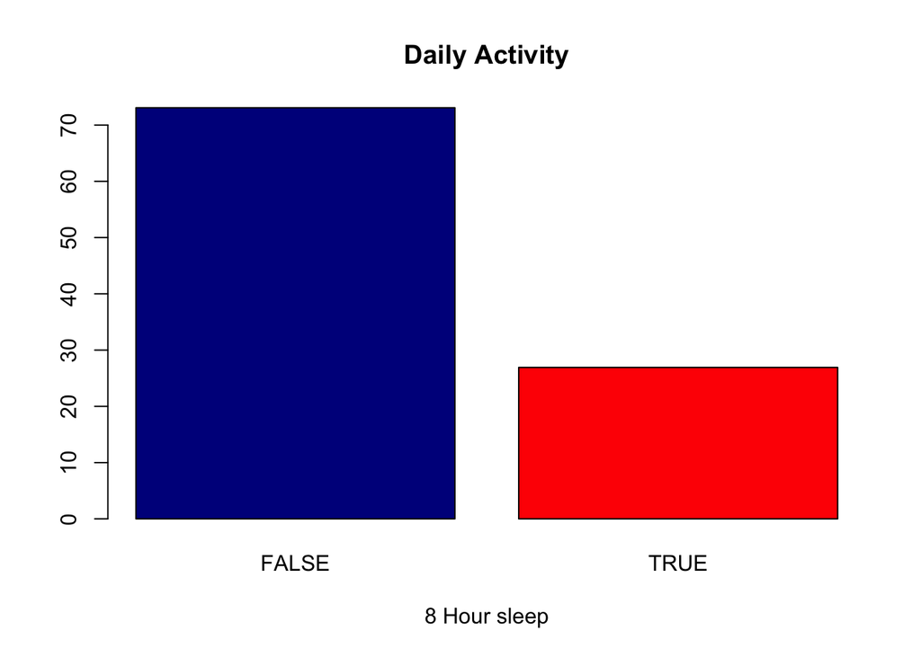

```r
data_percentage  <- apply(table(df$Sleep8h),1,function(x){x/sum(table(df$Sleep8h))*100})
barplot(data_percentage, main="Daily Activity",xlab="8 Hour sleep",col=c("darkblue","red"))
```

Podemos observar que en la mayoría de los casos se duerme menos de 8 horas.

También vamos a crear otra variable boolena que represente si una perosna es activa o no. La condición que debe cumplir es haber hecho 30 min de actividad muy activa y moderada, es decir que la suma de VeryActiveMinutes y FairlyActiveMinutes debe ser mayor a 30:

```r
df$IsActive <- ((df$VeryActiveMinutes+df$FairlyActiveMinutes)>=30)
head(df)
```

```
##           Id ActivityDate TotalSteps TotalDistance TrackerDistance
## 1 2026352035   2016-04-17        838          0.52            0.52
## 2 2026352035   2016-04-25       6017          3.73            3.73
## 3 2026352035   2016-05-02       7018          4.35            4.35
## 4 2026352035   2016-05-09      10685          6.62            6.62
## 5 2347167796   2016-04-13      10352          7.01            7.01
## 6 2347167796   2016-04-14      10129          6.70            6.70
##   VeryActiveDistance ModeratelyActiveDistance LightActiveDistance
## 1               0.00                     0.00                0.52
## 2               0.00                     0.00                3.73
## 3               0.00                     0.00                4.35
## 4               0.00                     0.00                6.60
## 5               1.66                     1.94                3.41
## 6               0.02                     2.74                3.94
##   VeryActiveMinutes FairlyActiveMinutes LightlyActiveMinutes SedentaryMinutes
## 1                 0                   0                   60             1053
## 2                 0                   0                  260              821
## 3                 0                   0                  355              716
## 4                 0                   0                  401              543
## 5                19                  32                  195              676
## 6                 1                  48                  206              705
##   Calories TotalMinutesAsleep TotalTimeInBed HeartrateMean Sleep8h IsActive
## 1     1214                437            498      68.65625   FALSE    FALSE
## 2     1576                506            531      99.50581    TRUE    FALSE
## 3     1690                511            543      84.13457    TRUE    FALSE
## 4     1869                531            556      98.23390    TRUE    FALSE
## 5     2038                467            531      73.81290   FALSE     TRUE
## 6     2010                445            489      72.57948   FALSE     TRUE
```

Vamos a ver como se distribuyen los diferentes casos:

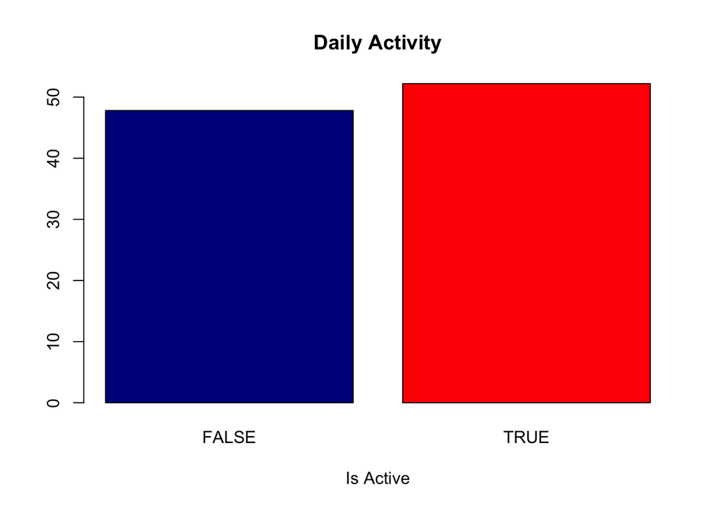

```r
data_percentage  <- apply(table(df$IsActive),1,function(x){x/sum(table(df$IsActive))*100})
barplot(data_percentage, main="Daily Activity",xlab="Is Active",col=c("darkblue","red"))
```

Podemos ver que se distribuye de forma muy diferente a la de Sleep8h en esta caso podemos ver que hay más gente activa que no.

```r
write.csv(df,"../datos_finales.csv")
```

# 5 Análisis de datos

## 5.1 Selección de grupos

Para nuestro caso de estudio queremos comprobar como afecta la actividad física y el tipo de actividad a nuestro nivel de sueño. Para ello vamos a utilizar las variables que muestran el numero de minutos por tipo de actividad:

- muy activa
- algo activa
- poco activa
- sedentaria

También vamos a utilizar las variables donde vemos reflejados el tiempo de sueño (TotalMinutesAsleep), la variable booleana que hemos creado en el apartado anterior. Representa si esa persona ha podido dormir más de ocho horas o no. Y la variable que representa si una persona es activa o no.

```r
head(df[c("Id","ActivityDate","VeryActiveMinutes","FairlyActiveMinutes","LightlyActiveMinutes", "SedentaryMinutes","TotalMinutesAsleep","Sleep8h","IsActive" )])
```

```
##           Id ActivityDate VeryActiveMinutes FairlyActiveMinutes
## 1 2026352035   2016-04-17                 0                   0
## 2 2026352035   2016-04-25                 0                   0
## 3 2026352035   2016-05-02                 0                   0
## 4 2026352035   2016-05-09                 0                   0
## 5 2347167796   2016-04-13                19                  32
## 6 2347167796   2016-04-14                 1                  48
##   LightlyActiveMinutes SedentaryMinutes TotalMinutesAsleep Sleep8h IsActive
## 1                   60             1053                437   FALSE    FALSE
## 2                  260              821                506    TRUE    FALSE
## 3                  355              716                511    TRUE    FALSE
## 4                  401              543                531    TRUE    FALSE
## 5                  195              676                467   FALSE     TRUE
## 6                  206              705                445   FALSE     TRUE
```

## 5.2 Normalidad y homogeneidad de la varianza

Primero vamos a comprobar la normalidad y la homogeneidad de la varizanza de la variable sobre la que queremos hacer el estudio. En este caso concreto los minutos de sueño.

Antes de nada vamos a graficar la variable para observar que tipo de distribución sigue:

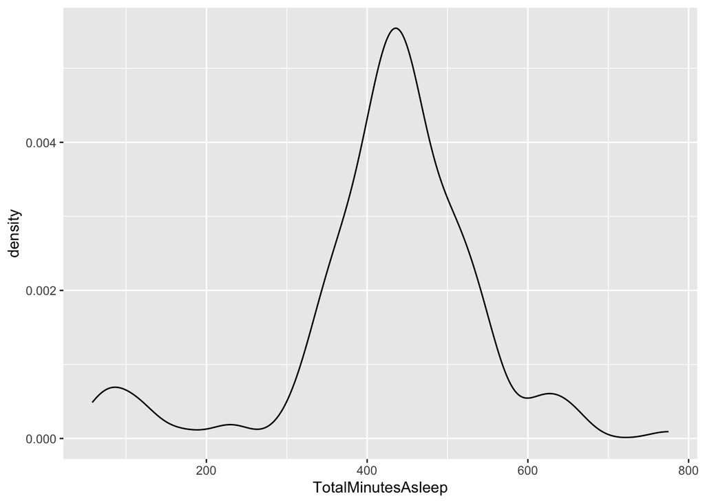

```r
library(ggplot2)
ggplot(df,aes(x=TotalMinutesAsleep))+geom_density()
```

Si solo nos centramos en la parte central de la gráfica si que podríamos decir que sigue una distribución normal pero en la parte izquierda de la gráfica hay un pico de casos por lo que no podemos afirmarlo.

Vamos a mostrar el gráfico QQ plot para confirmar si la variable sigue una distribución normal:

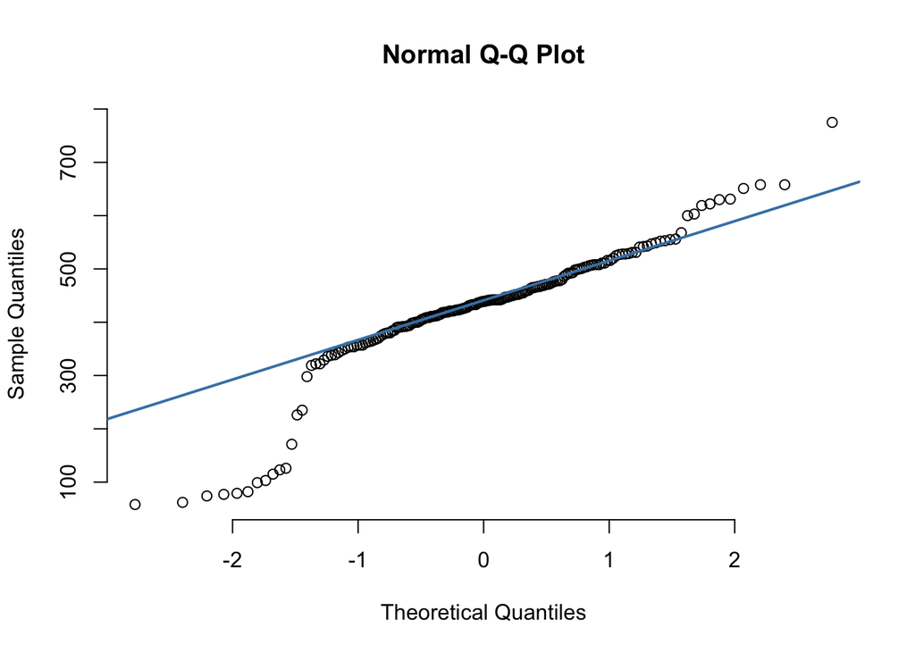

```r
qqnorm(df$TotalMinutesAsleep, pch = 1, frame = FALSE)
qqline(df$TotalMinutesAsleep, col = "steelblue", lwd = 2)
```

Para que los datos sigan una distribución normal los puntos deben ajustarse a la distribución teórica, que sería la linea diagonal. Como podemos observar en el gráfico no es el caso.

Igualmente como se trata de una muestra mayor a 30 observaciones, por lo que podemos aplicar el teorema central del limite y decir que la media sigue una distribución normal.

Lo siguiente que vamos a comprobar es si la varianza estadística de la variable TotalMinutesAsleep es igual o no a la varianza de la variable IsActive, que representa si una persona ha sido activa a lo largo del día o no. Consideremos que es activa si ha realizado 30 minutos o mas de actividad intensa o moderada.

```r
library(car)
df$IsActive <- as.factor(df$IsA)
leveneTest(TotalMinutesAsleep~IsActive,df)
```

```
## Levene's Test for Homogeneity of Variance (center = median)
##        Df F value Pr(>F)
## group   1  1.3007 0.2556
##       180
```

Obtenemos un p-valor mayor a 0.05, por lo que aceptamos la hipotiposis nula de homocedasticidad y concluimos que la varaible TotalMinutesAsleep tiene un varizanza estadísticamente similar a si una persona es activa o no.

## 5.3 Contraste de hipótesis

```r
t.test(TotalMinutesAsleep~IsActive,df)
```

```
##
##  Welch Two Sample t-test
##
## data:  TotalMinutesAsleep by IsActive
## t = 2.7172, df = 171.22, p-value = 0.007259
## alternative hypothesis: true difference in means between group FALSE and group TRUE is not equal to 0
## 95 percent confidence interval:
##  12.74652 80.44356
## sample estimates:
## mean in group FALSE  mean in group TRUE
##            450.8161            404.2211
```

El p-valor obtenido es menor a 0.05, es decir es menor al nivel de significancia, por lo que podemos decir que se observan estadísticamente significativas entre los grupos de datos IsActive y TotalMinuesAsleep.

## 5.4 Correlación

El coeficiente de correlación es una medida de la asociación entre dos variables. Este puede tomar valores entre -1 y 1, donde los extremos indican una correlación perfecta y el 0 indica la ausencia de correlación. El signo es negativo cuando valores elevados de una variable se asocian con valores pequeños de la otra, y el signo es positivo cuando ambas variables tienden a incrementar o disminuir simultáneamente.

Vamos a comprobar si hay correlación entre la variable de minutos totales que una persona a dormido y si es activa o no. Este coeficiente solo se puede calcular con variables numéricas. Por lo que como hemos utilizado la suma de los minutos de activada para crear la variable boolena IsActive vamos a calcular el coeficiente de correlación con ese mismo valor.

```r
cor.test(df$TotalMinutesAsleep,(df$VeryActiveMinutes+df$FairlyActiveMinutes))
```

```
##
##  Pearson's product-moment correlation
##
## data:  df$TotalMinutesAsleep and (df$VeryActiveMinutes + df$FairlyActiveMinutes)
## t = -1.1717, df = 180, p-value = 0.2429
## alternative hypothesis: true correlation is not equal to 0
## 95 percent confidence interval:
##  -0.22955202  0.05920334
## sample estimates:
##         cor
## -0.08700142
```

Obtenemos un nivel de correlación de -0.087, este valor esta bastante alejado de -1 por lo que el nivel de correlación es muy bajo.

## 5.5 Regresión

La regresión lineal es un modelo matemático que tiene como objetivo aproximar la relación de dependencia lineal entre una variable dependiente y una (o una serie) de variables independientes.

Vamos a comprobar si podemos estimar el número de total de minutos dormidos a partir de los minutos de activdidad

```r
ml = lm(TotalMinutesAsleep~VeryActiveMinutes+FairlyActiveMinutes+LightlyActiveMinutes+SedentaryMinutes,data=df)
summary(ml)
```

```
##
## Call:
## lm(formula = TotalMinutesAsleep ~ VeryActiveMinutes + FairlyActiveMinutes +
##     LightlyActiveMinutes + SedentaryMinutes, data = df)
##
## Residuals:
##     Min      1Q  Median      3Q     Max
## -392.21  -35.77   12.63   50.44  208.25
##
## Coefficients:
##                       Estimate Std. Error t value Pr(>|t|)
## (Intercept)          805.01917   37.14386  21.673  < 2e-16 ***
## VeryActiveMinutes     -0.20316    0.21734  -0.935  0.35119
## FairlyActiveMinutes   -0.92014    0.51061  -1.802  0.07324 .
## LightlyActiveMinutes  -0.23632    0.07547  -3.131  0.00204 **
## SedentaryMinutes      -0.43166    0.03769 -11.452  < 2e-16 ***
## ---
## Signif. codes:  0 '***' 0.001 '**' 0.01 '*' 0.05 '.' 0.1 ' ' 1
##
## Residual standard error: 88.32 on 177 degrees of freedom
## Multiple R-squared:  0.4417, Adjusted R-squared:  0.4291
## F-statistic: 35.01 on 4 and 177 DF,  p-value: < 2.2e-16
```

La medida de calidad del modelo es R-squared, toma valores entre 0 y 1. En nuestro caso toma un valor de 0.4417, es decir, nuestro modelo puede explicar el 44.17% de la variabilidad observada.

# 6 Conclusiones

En un estudio futuro, deberíamos realizar el estudio con la calidad del sueño, teniendo en cuenta cuánto de ese tiempo dormido pertenece a los diferentes estadios del sueño, fase del sueño ligero, etapa de transición, sueño profundo y fase REM. También podríamos considerar la relación entre el tiempo que el usuario pasa en la cama respecto al tiempo dormido e incorporar el registro del pulso durante los diferentes estadios del sueño para determinar el nivel de estrés.